# History of Philosophy: An Analysis on Stoicism

## Author: Yi Sun

### Uni: ys3594

## Part 1. General EDA

Before we jump into the story of Stoicism, let's have a look at the general picture of the dataset first. At this part, I mainly seperate the content by schools. Below we will gain the knowledge of the main words for each school by word clouds, amount of sentences by a pie chart, sentences length by the violin plot, and the sentiment analysis by boxplot!

```python
#Packages Import
import pandas as pd
import numpy as np
from pandas_profiling import ProfileReport
from wordcloud import WordCloud, STOPWORDS, ImageColorGenerator
import time
import matplotlib.pyplot as plt
from PIL import Image
import seaborn as sns
from nltk.sentiment import SentimentIntensityAnalyzer
import nltk
```

```python
#Read the csv file and saved as raw data
data_raw = pd.read_csv('philosophy_data.csv')
```

```python
#Copy the raw data for processing
data = data_raw.copy()
```

```python
#1.1 Check the columns
data.columns
```

```python
#1.2 Take a overview of the dataset
data.head()
```

```python
#1.3 Check the number of objects in each column and their data types
data.info()
```

```
<class 'pandas.core.frame.DataFrame'>
RangeIndex: 360808 entries, 0 to 360807
Data columns (total 11 columns):
 #   Column                     Non-Null Count   Dtype
---  ------                     --------------   -----
 0   title                      360808 non-null  object
 1   author                     360808 non-null  object
 2   school                     360808 non-null  object
 3   sentence_spacy             360808 non-null  object
 4   sentence_str               360808 non-null  object
 5   original_publication_date  360808 non-null  int64
 6   corpus_edition_date        360808 non-null  int64
 7   sentence_length            360808 non-null  int64
 8   sentence_lowered           360808 non-null  object
 9   tokenized_txt              360808 non-null  object
 10  lemmatized_str             360808 non-null  object
dtypes: int64(3), object(8)
memory usage: 30.3+ MB
```

```python
#Add sentiment score
# Add Sentiment Analysis columns
sia = SentimentIntensityAnalyzer()

# create a new column in the DataFrame to store the sentiment scores
data_sen = data.copy()
data_sen['sentiment_scores'] = data_sen['sentence_str'].apply(lambda x: sia.polarity_scores(x))

# extract the values from the sentiment_scores dictionary and assign them to new columns
# compound score ranges from -1 (neg) through 0 (neu) to 1 (pos)
data_sen['neg'] = data_sen['sentiment_scores'].apply(lambda x: x['neg'])
data_sen['neu'] = data_sen['sentiment_scores'].apply(lambda x: x['neu'])
data_sen['pos'] = data_sen['sentiment_scores'].apply(lambda x: x['pos'])
data_sen['compound_sent_score'] = data_sen['sentiment_scores'].apply(lambda x: x['compound'])

# Drop columns we are not going to use (all sentiment columns except of compund)
data_sen.drop(columns=['sentence_spacy','corpus_edition_date','sentiment_scores','pos','neg','neu'], inplace=True)
```

```python
#2.1 Play around with numerical features

#Aggregate the dataset by the school and author. At the same time, by calculating the mean of the numerical data,
#we can see the general publication date, corpus edition date, and average sentence length.

#data.groupby(by=['school','author']).mean().round()
```

```python
#2.2 General profile report

#By runing the profile report, we will generate a comprehensive report on value counts, correlation, and some fun interaction graphs.
profile = ProfileReport(data, title="Report of History of Philosophy")
```

```python
profile.to_file('EDA.html')
```

### 1.1 All schools and their own word clouds

```python
#2.3 Word Cloud
stopwords = set(STOPWORDS)
schools = data.school.unique().tolist()
```

```
School =  PLATO :
School =  ARISTOTLE :
School =  EMPIRICISM :
School =  RATIONALISM :
School =  ANALYTIC :
School =  CONTINENTAL :
School =  PHENOMENOLOGY :
School =  GERMAN_IDEALISM :
School =  COMMUNISM :
School =  CAPITALISM :
School =  STOICISM :
School =  NIETZSCHE :
School =  FEMINISM :
Elapsed time:  28.06
```

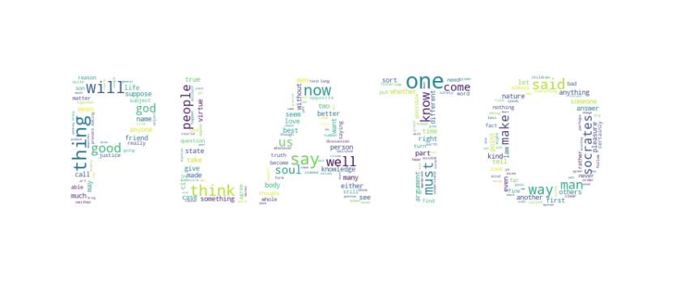

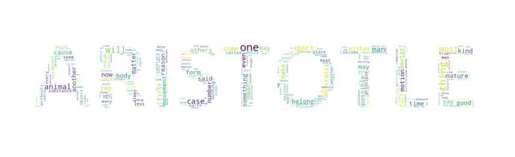

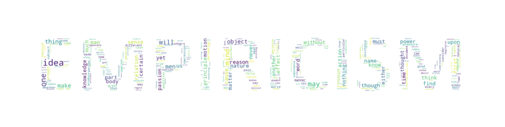

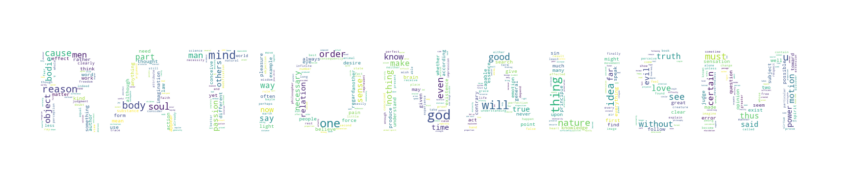

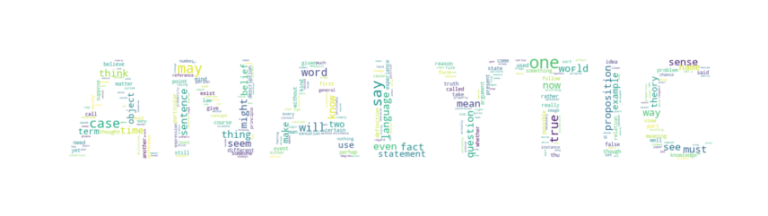

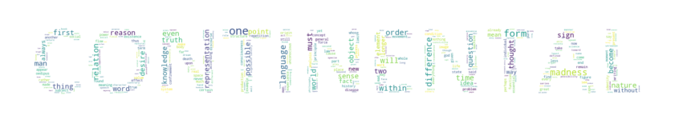

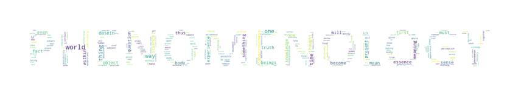

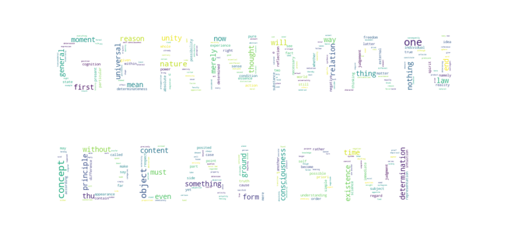

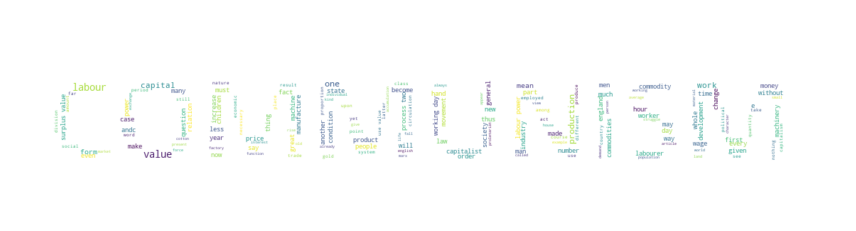

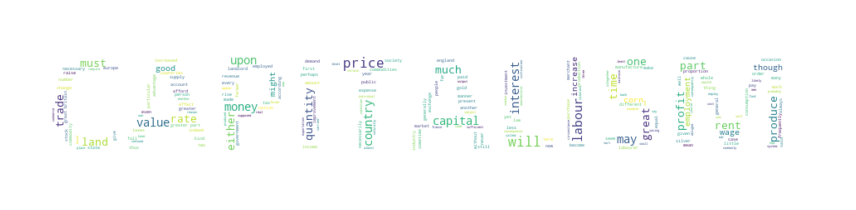

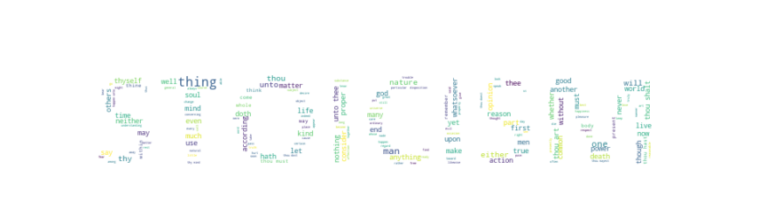

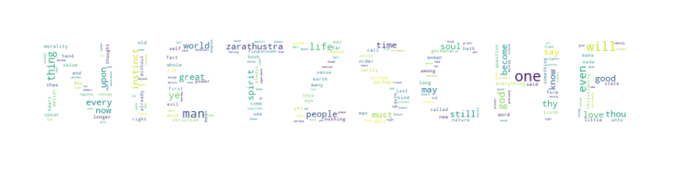

[1 more figures not shown]

```python
t1 = time.time()
for sc in schools:

    df_temp = data[data.school==sc]

    print('School = ', sc.upper(), ':')

    # render wordcloud
    mask = np.array(Image.open(f"{sc}.png"))
    text = " ".join(txt for txt in df_temp.sentence_lowered)
    wordcloud = WordCloud(stopwords=stopwords, max_font_size=50, max_words=500,
                          width = 600, height = 400,
                          background_color="white",mask = mask).generate(text)
    plt.figure(figsize=(12,8))
    plt.imshow(wordcloud, interpolation="bilinear")
    plt.axis("off")
    plt.tight_layout()
    plt.savefig(f"{sc}_cloud.png")
t2 = time.time()
print('Elapsed time: ', np.round(t2-t1,2))
```

### 1.2 Pie chart of the amount of sentences for each school

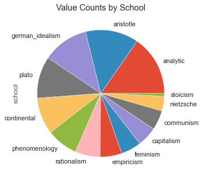

```python
#2.4 Categorical Value Count
# plot distributions of school and title

plt.figure(figsize=(20,5))
data['school'].value_counts().plot(kind='pie')
plt.title('Value Counts by School')
plt.grid()

plt.savefig('Pie_Value_Count_School.png')
```

```python
plt.figure(figsize=(20,7))
sns.violinplot(x='school', y='sentence_length', data=data)
plt.title('Sentence Length - By School')
plt.grid()
plt.savefig("Sentence_Len_Violin.png")
```

[output not shown]

### 1.4 Boxplot of sentiment analysis of each school

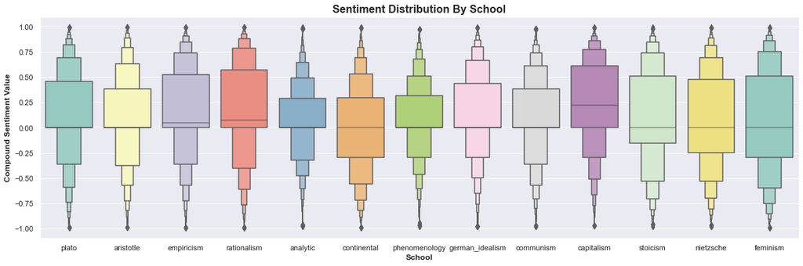

```python
# plot compound sentiment split by school
plt.figure(figsize=(20,6))
sns.set(font_scale=1)
sns.boxenplot(x='school', y='compound_sent_score', data=data_sen, palette="Set3")
plt.title('Sentiment Distribution By School', fontsize=16, fontweight='bold')
plt.xlabel('School', fontsize=12, fontweight='bold')
plt.ylabel('Compound Sentiment Value', fontsize=12, fontweight='bold')
plt.savefig('Sentiment_Dis_School.png')
```

# Part 2: Data Story

## An analysis on Stoicism

According to the definition on Google, Stoicism is defined as the endurance of pain or hardship without the display of feelings and without complaint. This sounds really cold,right? Like pains, hardship, and endurance. From my perspective, however, it is better to say it is a philosophy of life that maximizes positive emotions, reduces negative emotions and helps individuals to hone their virtues of character.

I want to dig deeper on Stoicism because this is the one I mostly agree with at my current stage by my personal understanding. Below I will share two my favorite sentences of this philosophy with my own interpretation, then, I will use some methodologies like word-to-vec and graphics to prove or disprove myself. At the same time, definitely we can had a better understanding of this minor philosophy and widen our view of the world!

```python
df_sto = data[data['school']=='stoicism']
```

```python
from gensim.models import Word2Vec
from gensim.utils import simple_preprocess
from gensim.test.utils import datapath, get_tmpfile
from gensim.scripts.glove2word2vec import glove2word2vec
from gensim.models import KeyedVectors
from gensim.models import Phrases
from gensim.models.phrases import Phraser
import ast
from scipy import spatial
from sklearn.decomposition import PCA
import adjustText
from matplotlib import pyplot

# a function for testing w2v pairs
def test_w2v(model, pairs):
  for (pos, neg) in pairs:
    math_result = model.most_similar(positive=pos, negative=neg)
    print(f'Positive - {pos}\tNegative - {neg}')
    [print(f"- {result[0]} ({round(result[1],5)})") for result in math_result[:5]]
    print()
```

```python
#Convert string to list
"""for x in df_sto['tokenized_txt']:
    x = ast.literal_eval(x)"""
```

```
"for x in df_sto['tokenized_txt']:\n    x = ast.literal_eval(x)"
```

```python
w2v_model = Word2Vec(df_sto['tokenized_txt'], min_count=1)
```

### 2.1 First Sentence

"Some things are in our control and others not. Things in our control are opinion, pursuit, desire, aversion, and, in a word, whatever are our own actions. Things not in our control are body, property, reputation, command, and, in one word, whatever are not our own actions. #enchiridion 1".

I really appreciate this sentence because it provides a better explanation of my doctrine, which is from the Serenity Prayer by Niebuhr:

"God, Grant me the SERENITY, to accept the things I cannot change, COURAGE to change the things I can, and the WISDOM to know the difference.".

I highly believe the unsatisfaction of anything is due to our unreal higher estimation. Face the truth and reality, accept the limit and weakness is the best way to live with myself from my perspective. But sometimes, it is hard to distinguish between those two things, fortunately, Stoicism provides us a baseline.

I'd like to check the explanations of "control", “opinion”, and "command" to testify my understanding and more details will be presented in the following blocks.

```python
print("Most similar words to 'control': ", w2v_model.wv.most_similar('control'))
```

[output not shown]

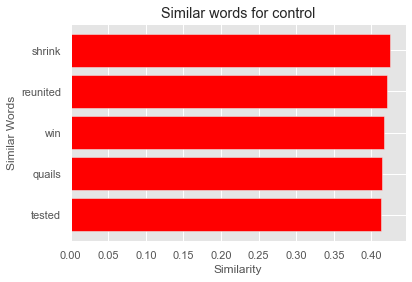

```python
sims = w2v_model.wv.most_similar('control', topn=5)

sim_word = []
sim_str  = []
for i in range(len(sims)):
    sim_word.append(sims[i][0])
for i in range(len(sims)):
    sim_str.append(sims[i][1])
sim_word = list(reversed(sim_word))
sim_str  = list(reversed(sim_str))


import matplotlib.pyplot as plt
y = sim_word
x = sim_str
plt.style.use('ggplot')
plt.barh(y,x,color=['red'])
plt.title('Similar words for control')
plt.ylabel('Similar Words')
plt.xlabel('Similarity')
plt.savefig('Control_sim.png')
```

```python
print("Most similar words to 'command': ", w2v_model.wv.most_similar('command'))
```

```
Most similar words to 'command':  [('effect', 0.9862580299377441), ('elements', 0.9862156510353088), ('justice', 0.9860260486602783), ('new', 0.985916018486023), ('man', 0.985895037651062), ('thing', 0.9858225584030151), ('place', 0.9857990741729736), ('socrates', 0.985788881778717), ('earth', 0.985…
```

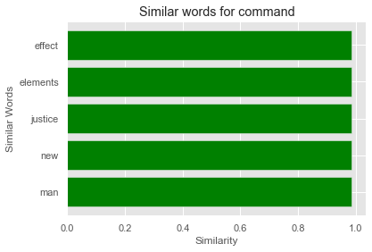

```python
sims = w2v_model.wv.most_similar('command', topn=5)

sim_word = []
sim_str  = []
for i in range(len(sims)):
    sim_word.append(sims[i][0])
for i in range(len(sims)):
    sim_str.append(sims[i][1])
sim_word = list(reversed(sim_word))
sim_str  = list(reversed(sim_str))


import matplotlib.pyplot as plt
y = sim_word
x = sim_str
plt.style.use('ggplot')
plt.barh(y,x,color=['green'])
plt.title('Similar words for command')
plt.ylabel('Similar Words')
plt.xlabel('Similarity')

plt.savefig("command_sim.png")
```

```python
print("Most similar words to 'opinion': ", w2v_model.wv.most_similar('opinion'))
```

```
Most similar words to 'opinion':  [('or', 0.9994271397590637), ('upon', 0.9994078278541565), ('their', 0.99940025806427), ('itself', 0.9993995428085327), ('men', 0.9993937015533447), ('good', 0.9993930459022522), ('by', 0.9993925094604492), ('and', 0.9993923902511597), ('his', 0.9993685483932495), (…
```

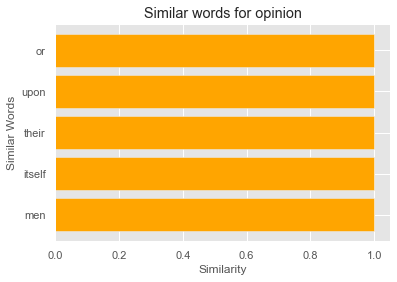

```python
sims = w2v_model.wv.most_similar('opinion', topn=5)

sim_word = []
sim_str  = []
for i in range(len(sims)):
    sim_word.append(sims[i][0])
for i in range(len(sims)):
    sim_str.append(sims[i][1])
sim_word = list(reversed(sim_word))
sim_str  = list(reversed(sim_str))


import matplotlib.pyplot as plt
y = sim_word
x = sim_str
plt.style.use('ggplot')
plt.barh(y,x,color=['orange'])
plt.title('Similar words for opinion')
plt.ylabel('Similar Words')
plt.xlabel('Similarity')

plt.savefig('Opinion_sim.png')
```

### 2.2 Second Sentence

"Remember, that not he who gives ill language or a blow insults, but the principle which represents these things as insulting. When, therefore, anyone provokes you, be assured that it is your own opinion which provokes you. #enchiridion 20".

I listed this sentence because I think it is the essence of freedom in spirit. Sometimes, we feel painful by blames because we are afraid of accepting the reality, or refuse to. We want to hide it. Reality cannot be hidden, it is always there. No one can hurt us is not a nonsense. With a strong heart, accurate understanding of myself, we are able to open to all ideas because we know most of them are untrue. Others cannot feel the exactly same way as us, so open to opinions but evaluate them by ourselves.

```python
print("Most similar words to 'ill': ", w2v_model.wv.most_similar('ill'))
```

[output not shown]

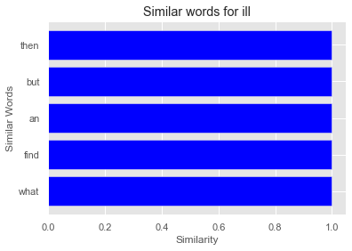

```python
sims = w2v_model.wv.most_similar('ill', topn=5)

sim_word = []
sim_str  = []
for i in range(len(sims)):
    sim_word.append(sims[i][0])
for i in range(len(sims)):
    sim_str.append(sims[i][1])
sim_word = list(reversed(sim_word))
sim_str  = list(reversed(sim_str))


import matplotlib.pyplot as plt
y = sim_word
x = sim_str
plt.style.use('ggplot')
plt.barh(y,x,color=['blue'])
plt.title('Similar words for ill')
plt.ylabel('Similar Words')
plt.xlabel('Similarity')

plt.savefig('Ill_sim.png')
```

```python
print("Most unsimilar words to 'control': ", w2v_model.wv.most_similar(negative = ['control']))
```

```
Most unsimilar words to 'control':  [('forceth', 0.289644718170166), ('striving', 0.2818538546562195), ('beams', 0.2640213966369629), ('caesars', 0.2553884983062744), ('defect', 0.2140348106622696), ('giver', 0.21063977479934692), ('diverted', 0.20581428706645966), ('disagreeth', 0.20535290241241455…
```

```python
#Graphic of W2V, failed
"""mod = w2v_model.wv[w2v_model.wv.key_to_index]
pca = PCA(n_components = 3)
result = pca.fit_transform(mod)
pyplot.scatter(result[2845:2846,0],result[2845:2846,1])
words = list(w2v_model.wv.key_to_index)
for i, word in enumerate(words):
    pyplot.annotate(word, xy = (result[i,0], result[i,1]))
pyplot.show()"""
```

[output not shown]

There is one conflict I want to mention is about the word "control". There are two types of similiar words: first type is a little negative, like "shrink", "quails", amd "impertinent". Another type is more positive like "reunited", "win", and "thankful".

```python
df_sto_sen = data_sen[data_sen['school'] == 'stoicism']
```

```python
#Sentiment Analysis focus on Stoicism. Result insignificant
"""plt.figure(figsize=(16,6))
sns.lineplot(data=df_sto_sen, x='original_publication_date', y='compound_sent_score', linestyle='--', color='red')
plt.grid(True)
plt.xlabel('Year', fontsize=14, fontweight='bold')
plt.ylabel('Compound Sentiment Score', fontsize=14, fontweight='bold')
plt.title("Sentiment Score Across Time", fontsize=16, fontweight='bold')
plt.show()"""
```

[output not shown]

```python
temp = df_sto.groupby('original_publication_date').size()
```

### 2.3 Since all sentences of Stoicism concentrated on these two years, so let's compare them to see whether there is anything interesting.

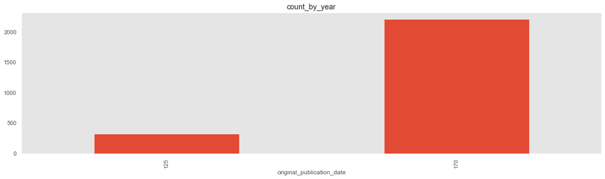

```python
plt.figure(figsize=(20,5))
temp.plot(kind='bar')
plt.title('count_by_year')
plt.grid()
plt.savefig('Sto_Count_Year.png')
```

```python
df125 = df_sto[df_sto['original_publication_date'] == 125]
df170 = df_sto[df_sto['original_publication_date'] == 170]
```

```python
from collections import Counter
highlight125 = []
highlight170 = []
for words in df125['tokenized_txt']:
    for word in words:
        highlight125.append(word)

for words in df170['tokenized_txt']:
    for word in words:
        highlight170.append(word)

highlight125_clean = []
for word in highlight125:
    if word not in stopwords:
        highlight125_clean.append(word)

highlight170_clean = []
for word in highlight170:
    if word not in stopwords:
        highlight170_clean.append(word)
```

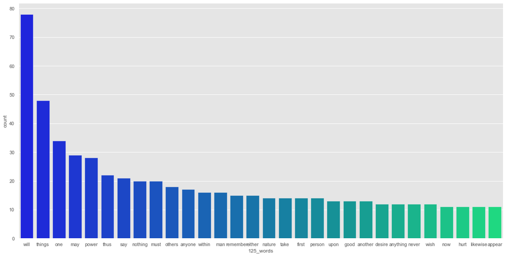

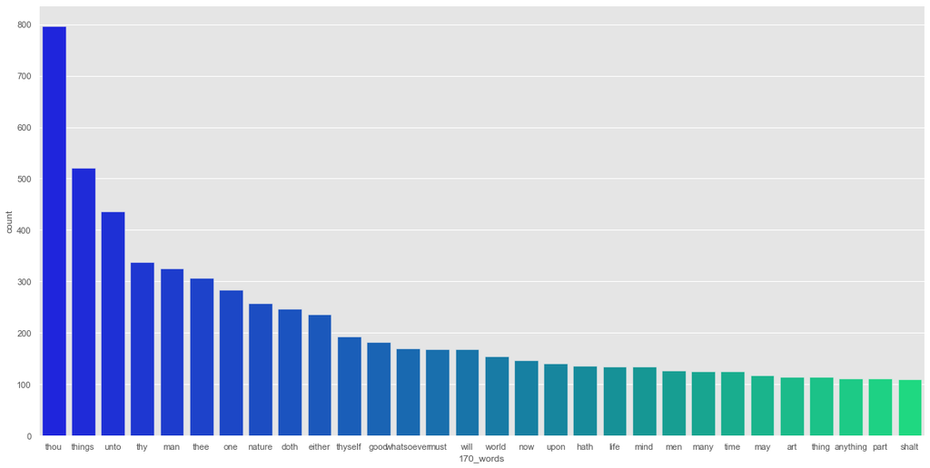

```python
most_frequent125 = Counter(highlight125_clean).most_common(30)

fig = plt.figure(1, figsize = (20,10))
_ = pd.DataFrame(most_frequent125, columns=("125_words","count"))
sns.barplot(x = '125_words', y = 'count', data = _, palette = 'winter')
plt.show()




most_frequent170 = Counter(highlight170_clean).most_common(30)

fig = plt.figure(1, figsize = (20,10))
_ = pd.DataFrame(most_frequent170, columns=("170_words","count"))
sns.barplot(x = '170_words', y = 'count', data = _, palette = 'winter')
plt.show()
```